# RBIF114_HW2_TCGA_revision_7.26

Rhema Francis

2026-07-02

# Assignment 2: RNA-Seq Pipeline for Differential Expression

## Package Setup

```r
install.packages("BiocManager")
BiocManager::install(c("GEOquery", "DESeq2"), ask = FALSE, update = FALSE)
install.packages(c("ggplot2", "dplyr", "knitr"))
```

```r
library(GEOquery)
library(DESeq2)
library(ggplot2)
library(dplyr)
library(knitr)
```

## 1. Introduction

The R Markdown contains the code to walk through an end-to end gene-level RNA-seq differential expression analysis using Bioconductor packages. This workflow begins with a pre-processed gene-level count matrix obtained from GEO and proceeds through downstream differential expression analysis. Differential expression analysis will be performed via t-test, before and after Benjamini-Hochberg correction, and then via DESeq2 analysis.

### 1.1 Biomarker Dataset

The GEO dataset used in this workflow is GSE184717, obtained from a rapid-autopsy study of metastatic breast cancer (Huang et al., 2021, Genome Medicine). Unlike many case-control gene expression studies that include samples from many different patients, this dataset contains 42 samples collected from a single patient with triple-negative metastatic breast cancer. The dataset includes 28 gross tumor biopsies and 14 adjacent normal tissue samples, obtained via rapid-autopsy across multiple organs.The implications of this study design are discussed further in section 1.4.

### 1.2 Research Question

The goal of this study is to identify genes that are differentially expressed between metastatic breast tumor biopsies and adjacent normal tissue within this patient. More specifically, this study investigates the gene expression changes associated with metastatic colonization in triple-negative breast cancer. Since all the samples originate from a single patient, the findings could help identify dysregulated genes across multiple independent metastatic sites, and highlight pathways relevant to metastatic disease progression and potential therapeutic agents (Huang et al., 2021, Genome Medicine).

### 1.3 Study Design

The dataset comes from a rapid-autopsy of a 45-year old patient with triple-negative breast cancer. Tissue samples were collected from multiple organs approximately two hours after death and consisted of 28 metastatic tumor samples and 14 adjacent normal tissue samples (Huang et al., 2021, Genome Medicine).

### 1.4 Biological and Technical Replicates

No technical replicates were reported for this dataset because each of the 42 samples represents a distinct tissue biopsy (Huang et al., 2021, Genome Medicine). However, since the samples were collected from a single patient, the samples can’t be considered as biological replicates in the “traditional” sense. Instead, the 28 tumor and 14 normal samples are spatial pseudoreplicates, because of the repeated sampling of the same subject at different sites (Zimmerman et al., 2021). Any samples found differentially expressed should therefore be interpreted as potential markers for this patient only, rather than biomarkers for breast cancer as a whole, until validated in larger, independent cohorts.

### 1.5 Statistical Power

Typically, a dataset with 28 tumor and 14 normal samples would have good statistical power to indentify differentially expressed genes. However, since all the samples came from a single patient, the ability to make generalizations is limited (Heumos et al., 2023). The study has strong power to characterize this specific patient’s metastatic gene expression, but limited power to make general conclusions about breast cancer in other patients.

## 2. Data Acquistion and Preprocessing

GEO stores the count matrix and sample metadata in separate files, so they were downloaded independently and matched using their sample IDs.

#### 2.1 Download and load sample metadata

```r
# Download series matrix, only has sample metadata, not expression data
gse <- getGEO("GSE184717", GSEMatrix = TRUE)
```

```
## Found 1 file(s)
```

```
## GSE184717_series_matrix.txt.gz
```

```r
eset <- gse[[1]]

# Extract phenotype/sample metadata
pheno <- pData(eset)

sample_info <- pheno[, c("title", "source_name_ch1", "tissue:ch1", "cell type:ch1")]
colnames(sample_info) <- c("title", "source_name", "tissue_site", "cell_type")

# Check dimensions
dim(sample_info)
```

```
## [1] 42  4
```

```r
head(sample_info)
```

```
##              title                         source_name             tissue_site
## GSM5596074     Ln5 breast cancer lung metastatic tumor breast metastatic tumor
## GSM5596075     Ln6 breast cancer lung metastatic tumor breast metastatic tumor
## GSM5596076     Ln7 breast cancer lung metastatic tumor breast metastatic tumor
## GSM5596077 Ln7-adj     Ln7 adjacent normal lung tissue                    lung
## GSM5596078     Ln8 breast cancer lung metastatic tumor breast metastatic tumor
## GSM5596079 Ln8-adj     Ln8 adjacent normal lung tissue                    lung
##            cell_type
## GSM5596074    cancer
## GSM5596075    cancer
## GSM5596076    cancer
## GSM5596077    normal
## GSM5596078    cancer
## GSM5596079    normal
```

### 2.2 Download and Load Count Matrix

```r
options(timeout = 300)

getGEOSuppFiles("GSE184717", baseDir = "data", makeDirectory = TRUE)
```

[output not shown]

```r
count_file <- list.files(
  "data/GSE184717",
  pattern = "featureCountMatrix",
  full.names = TRUE
)

# Read the count matrix
counts <- read.table(
  gzfile(count_file),
  header = TRUE,
  row.names = 1,
  check.names = FALSE
)

# Check dimensions
dim(counts)
```

```
## [1] 23368    42
```

```r
head(counts[, 1:5])
```

```
##           Ln5 Ln6 Ln7 Ln7-adj Ln8
## DDX11L1     6   6   3       1   3
## WASH7P    252 196 124      99 206
## FAM138F     0   0   0       0   0
## FAM138A     0   0   0       0   0
## OR4F5       0   0   2       0   0
## LOC729737  77  61  75      88  66
```

```r
colnames(counts)
```

```
##  [1] "Ln5"       "Ln6"       "Ln7"       "Ln7-adj"   "Ln8"       "Ln8-adj"
##  [7] "Ln12"      "Ln12-adj"  "Ln12-dist" "Ln10"      "Sk1"       "Ln11"
## [13] "Kd1"       "Bn3"       "Bn2"       "Lv1"       "Bo1"       "Bo3"
## [19] "Lv4"       "Ly1"       "Bn1"       "Ln1"       "Lv3"       "Ly2"
## [25] "Ln9"       "Ln2-adj"   "Ln2-dist"  "Ln5-adj"   "Ln6-adj"   "Kd1-adj"
## [31] "Kd1-dist"  "Pa1"       "Ln1-adj"   "Bn4"       "Lv2"       "Bo2"
## [37] "Ln1-dist"  "Ln2"       "Ln3"       "Ln4"       "Ln4-adj"   "Ln4-dist"
```

### 2.3 Align Sample Metadata to Count Matrix

```r
sample_info <- sample_info[match(colnames(counts), sample_info$title), ]

all(sample_info$title == colnames(counts))
```

```
## [1] TRUE
```

```r
rownames(sample_info) <- sample_info$title

sample_info$cell_type <- factor(sample_info$cell_type, levels = c("normal", "cancer"))

table(sample_info$cell_type)
```

```
##
## normal cancer
##     14     28
```

```r
table(sample_info$tissue_site)
```

```
##
## breast metastatic tumor                  kidney                    lung
##                      27                       2                      12
##           peri-pancreas
##                       1
```

### 2.4 Remove low count genes

```r
keep_genes <- rowSums(counts) >= 10

counts_filtered <- counts[keep_genes, ]

dim(counts_filtered)
```

```
## [1] 22507    42
```

## 3. QC Exploratory Data Analysis

### 3.1 Build DESeq2 dataframe for PCA

```r
dds <- DESeqDataSetFromMatrix(
  countData = counts_filtered,
  colData = sample_info,
  design = ~ cell_type
)

dds
```

```
## class: DESeqDataSet
## dim: 22507 42
## metadata(1): version
## assays(1): counts
## rownames(22507): DDX11L1 WASH7P ... NLGN4Y CD24
## rowData names(0):
## colnames(42): Ln5 Ln6 ... Ln4-adj Ln4-dist
## colData names(4): title source_name tissue_site cell_type
```

### 3.2 Transform raw count data to stabilize variance for QC

```r
vsd <- vst(dds, blind = TRUE)
```

### 3.3 Extract PCA Data

```r
pca_df <- plotPCA(vsd, intgroup = c("cell_type", "tissue_site"), returnData = TRUE)

percentVar <- round(100 * attr(pca_df, "percentVar"))
```

#### 3.4 PCA Plot

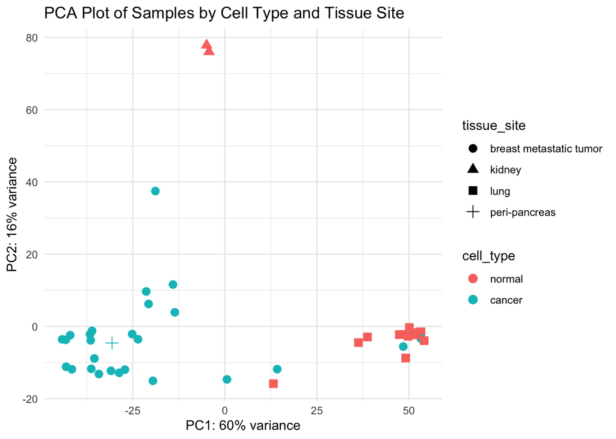

```r
ggplot(pca_df, aes(PC1, PC2, color = cell_type, shape = tissue_site)) + geom_point(size = 3) +
  xlab(paste0("PC1: ", percentVar[1], "% variance")) +
  ylab(paste0("PC2: ", percentVar[2], "% variance")) +
  theme_minimal() +
  ggtitle("PCA Plot of Samples by Cell Type and Tissue Site")
```

PC1 explained 60% of the total variance and mostly separated the tumor and normal samples into distinct clusters.

## 4. Differential Expression Analysis

### 4.1 DESeq2 Analysis

#### 4.1.1 Run DESeq2

```r
dds <- DESeq(dds)
```

```
## -- replacing outliers and refitting for 914 genes
## -- DESeq argument 'minReplicatesForReplace' = 7
## -- original counts are preserved in counts(dds)
```

#### 4.1.2 Extract Results

```r
results_deseq <- results(dds)

summary(results_deseq)
```

```
##
## out of 22507 with nonzero total read count
## adjusted p-value < 0.1
## LFC > 0 (up)       : 10765, 48%
## LFC < 0 (down)     : 5263, 23%
## outliers [1]       : 0, 0%
## low counts [2]     : 0, 0%
## (mean count < 0)
## [1] see 'cooksCutoff' argument of ?results
## [2] see 'independentFiltering' argument of ?results
```

```r
head(results_deseq)
```

```
## log2 fold change (MLE): cell type cancer vs normal
## Wald test p-value: cell type cancer vs normal
## DataFrame with 6 rows and 6 columns
##               baseMean log2FoldChange     lfcSE      stat      pvalue
##              <numeric>      <numeric> <numeric> <numeric>   <numeric>
## DDX11L1       14.82814       2.958322  0.591285   5.00321 5.63836e-07
## WASH7P       152.84544       0.691766  0.169970   4.06992 4.70286e-05
## OR4F5          1.98872       3.899872  1.050119   3.71374 2.04216e-04
## LOC729737     85.08043       0.653847  0.317111   2.06188 3.92187e-02
## LOC100133331  62.64698       0.859620  0.254347   3.37971 7.25628e-04
## LOC100288069  30.07053       1.147235  0.247788   4.62991 3.65823e-06
##                     padj
##                <numeric>
## DDX11L1      3.06315e-06
## WASH7P       1.42574e-04
## OR4F5        5.25345e-04
## LOC729737    5.84760e-02
## LOC100133331 1.63007e-03
## LOC100288069 1.52332e-05
```

```r
# Number or significant results at padj < 0.05
sum(results_deseq$padj < 0.05, na.rm = TRUE)
```

```
## [1] 14829
```

### 4.2 Differential Expression using a T-test

The t-test used the DESeq2-normalized counts so that both methods were compared using the same normalized data.

#### 4.2.1 Pull normalized counts from dds

```r
norm_counts <- counts(dds, normalized = TRUE)

dim(norm_counts)
```

```
## [1] 22507    42
```

```r
head(norm_counts[, 1:5])
```

```
##                    Ln5        Ln6        Ln7    Ln7-adj        Ln8
## DDX11L1        5.99196   5.747589   4.036594   1.118669   2.747988
## WASH7P       251.66232 187.754586 166.845901 110.748217 188.695191
## OR4F5          0.00000   0.000000   2.691063   0.000000   0.000000
## LOC729737     76.89682  58.433825 100.914860  98.442860  60.455741
## LOC100133331 114.84590  85.255909 110.333580  64.882794  56.791756
## LOC100288069  51.93032  39.275194  25.565098  16.780033  60.455741
```

#### 4.2.2 Log2 Transform

```r
log_norm_counts <- log2(norm_counts + 1)

dim(log_norm_counts)
```

```
## [1] 22507    42
```

```r
head(log_norm_counts[, 1:5])
```

```
##                   Ln5      Ln6      Ln7  Ln7-adj      Ln8
## DDX11L1      2.805697 2.754372 2.332449 1.083158 1.906116
## WASH7P       7.981067 7.560368 7.390993 6.804108 7.567539
## OR4F5        0.000000 0.000000 1.884036 0.000000 0.000000
## LOC729737    6.283493 5.893212 6.671221 6.635796 5.941476
## LOC100133331 6.856063 6.430551 6.798745 6.041830 5.852792
## LOC100288069 5.726022 5.331820 4.731460 4.152186 5.941476
```

#### 4.2.3 T-test before correction

```r
group <- sample_info$cell_type

ttest_pvalues <- apply(log_norm_counts, 1, function(x) {t.test(x[group == "cancer"], x[group == "normal"])$p.value})

length(ttest_pvalues)
```

```
## [1] 22507
```

```r
head(ttest_pvalues)
```

```
##      DDX11L1       WASH7P        OR4F5    LOC729737 LOC100133331 LOC100288069
## 1.140964e-04 8.782283e-05 9.964710e-05 1.254562e-01 3.164695e-03 5.519597e-05
```

#### 4.2.4 Count significant genes before correction

```r
sig_before <- sum(ttest_pvalues < 0.05, na.rm = TRUE)

cat("Significant Genes before correction:", sig_before)
```

```
## Significant Genes before correction: 15205
```

#### 4.2.5 Apply B-H Correction

```r
ttest_padj <- p.adjust(ttest_pvalues, method = "BH")
```

#### 4.2.6 Significant genes after BH correction

```r
sig_after <- sum(ttest_padj < 0.05, na.rm = TRUE)

cat("Significant genes after BH correction:", sig_after)
```

```
## Significant genes after BH correction: 14434
```

The t-test initially identified 15,205 significant before multiple testing correction (p-value < 0.05). After Benjamini-Hochberg correction, 14,434 genes remained significant.

Compared to many RNA-seq differential expression studies, the decrease after B-H correction was relatively small (Conesa et al., 2016). The small change is probably because most of the p-values were already small. This likely ties back to the study design, since all samples came from a single patient. There was less natural variation than would be expected in a multi-patient study, which makes it easier to detect significant differences between tumor and normal tissue.

### 4.3 Compare BH adjusted t-test and DESeq2

To compare the B-H adjusted t-test and DESeq2, the overlap in significant genes between the two methods was calculated.

```r
# Post-BH t-test significant genes
ttest_sig_genes <- names(ttest_padj)[ttest_padj < 0.05]

length(ttest_sig_genes)
```

```
## [1] 14434
```

```r
#  DESeq2 Genes significant genes
deseq_sig_genes <- rownames(results_deseq)[!is.na(results_deseq$padj) & results_deseq$padj < 0.05]

length(deseq_sig_genes)
```

```
## [1] 14829
```

```r
# Overlap between the two methods
overlap <- intersect(ttest_sig_genes, deseq_sig_genes)

length(overlap)
```

```
## [1] 13453
```

DESeq2 identified 14,829 significant genes (padj < 0.05), compared with 14,434 identified by the post-BH t-test.

The two gene lists overlapped by 13,453 significant genes identified by both methods which shows a strong agreement between the two. The t-test was performed on log-transformed, DESeq2-normalized data, while DESeq2 used used a negative binomial linear model on raw normalized counts.

Each method also identified a small amount of genes that the other didn’t. The t-test identified 981 genes, and DESeq2 identified 1,376. This is consistent with the way DESeq2’s analyzes RNA-seq data; by using dispersion-shrinkage to share information across genes to estimate variability. It can detect some genes that a t-test may overlook (Love et al., 2014).

## 5. Summary and Conclusions

This workflow successfully compared two differential expression analyses on a single-patient rapid-autopsy dataset and found strong agreement between the results. However, the single-patient design means these findings are specific to this individual and cannot be generalized to all breast cancer patients without validation in independent cohorts.

## References:

Conesa, A., Madrigal, P., Tarazona, S., Gomez-Cabrero, D., Cervera, A., McPherson, A., Szcześniak, M. W., Gaffney, D. J., Elo, L. L., Zhang, X., & Mortazavi, A. (2016). A survey of best practices for RNA-seq data analysis. Genome biology, 17, 13. https://doi.org/10.1186/s13059-016-0881-8

Heumos, L., Schaar, A. C., Lance, C., Litinetskaya, A., Drost, F., Zappia, L., Lücken, M. D., Strobl, D. C., Henao, J., Curion, F., Schiller, H. B., & Theis, F. J. (2023). Best practices for single-cell analysis across modalities. Nature Reviews Genetics, 24(8), 1–23. https://doi.org/10.1038/s41576-023-00586-w

Huang, X., Qiao, Y., Brady, S. W., Factor, R. E., Downs-Kelly, E., Farrell, A., McQuerry, J. A., Shrestha, G., Jenkins, D., Johnson, W. E., Cohen, A. L., Bild, A. H., & Marth, G. T. (2021). Novel temporal and spatial patterns of metastatic colonization from breast cancer rapid-autopsy tumor biopsies. Genome Medicine, 13(1), 170. https://doi.org/10.1186/s13073-021-00989-6

Love, M. I., Huber, W., & Anders, S. (2014). Moderated estimation of fold change and dispersion for RNA-seq data with DESeq2. Genome biology, 15(12), 550. https://doi.org/10.1186/s13059-014-0550-8